# SNPassoc: an R package to perform whole genome association studies

Juan R. Gonzalez and Victor Moreno

Bioinformatics Research Group in Epidemiolgy (BRGE), Barcelona Institute for Global Health (ISGlobal)  
Department of Mathematics, Autonomous University of Barcelona (UAB)  
Catalan Institute of Oncology

juanr.gonzalez@isglobal.org

2020-11-10

#### Package

SNPassoc 2.0.2

# 1 Introduction

The `SNPassoc` package contains facilities for data manipulation, tools for exploratory data analysis, convenient graphical facilities, and tools for assessing genetic association for both quantitative and categorial (case-control) traits in whole genome approaches. Genome-based studies are normally analyzed using a multistage approach. In the first step researchers are interested in assessing association between the outcome and thousands of SNPs. In a second and possibly third step, medium/large scale studies are performed in which only a few hundred of SNPs, those with a putative association found in the first step, are genotyped. `SNPassoc` is specially designed for analyzing this kind of designs. In addition, a convenience-based approach (select variants on the basis of logistical considerations such as the ease and cost of genotyping) can also be analyzed using `SNPassoc`. Different genetic models are also implemented in the package. Analysis of multiple SNPs can be analyzed using either haplotype or gene-gene interaction approaches.

This document is an updated version of the initial vignette that was published with the SNPassoc paper González et al. (2007). It contains a more realistic example belonging to a real dataset. The original vignette is still available [here](https://github.com/isglobal-brge/TeachingMaterials/blob/master/Master_Bioinformatics/Recommended_lectures/SupplementaryMaterial-BIOINF-2006-1602.R1.pdf).

# 2 Data loading

SNP data are typically available in text format or Excel spreadsheets which are easily uploaded in `R` as a data frame. Here, as an illustrative example, we are analyzing a dataset containing epidemiological information and 51 SNPs from a case-control study on asthma. The data is available within `SNPassoc` and can be loaded by

Then, the data is loaded into the R session by

```r
data(asthma, package = "SNPassoc")
str(asthma, list.len=9)
```

```
'data.frame':   1578 obs. of  57 variables:
 $ country    : Factor w/ 10 levels "Australia","Belgium",..: 5 5 5 5 5 5 5 5 5 5 ...
 $ gender     : Factor w/ 2 levels "Females","Males": 2 2 2 1 1 1 1 2 1 1 ...
 $ age        : num  42.8 50.2 46.7 47.9 48.4 ...
 $ bmi        : num  20.1 24.7 27.7 33.3 25.2 ...
 $ smoke      : int  1 0 0 0 0 1 0 0 0 0 ...
 $ casecontrol: int  0 0 0 0 1 0 0 0 0 0 ...
 $ rs4490198  : Factor w/ 3 levels "AA","AG","GG": 3 3 3 2 2 2 3 2 2 2 ...
 $ rs4849332  : Factor w/ 3 levels "GG","GT","TT": 3 2 3 2 1 2 3 3 2 1 ...
 $ rs1367179  : Factor w/ 3 levels "CC","GC","GG": 2 2 2 3 3 3 2 3 3 3 ...
  [list output truncated]
```

```r
asthma[1:5, 1:8]
```

```
  country  gender      age      bmi smoke casecontrol rs4490198 rs4849332
1 Germany   Males 42.80630 20.14797     1           0        GG        TT
2 Germany   Males 50.22861 24.69136     0           0        GG        GT
3 Germany   Males 46.68857 27.73230     0           0        GG        TT
4 Germany Females 47.86311 33.33187     0           0        AG        GT
5 Germany Females 48.44079 25.23634     0           1        AG        GG
```

# 3 Descriptive analysis

To start the analysis, we must indicate which columns of the dataset `asthma` contain the SNP data, using the `setupSNP` function. In our example, SNPs start from column 7 onwards, which we specify in argument *colSNPs*

```r
library(SNPassoc)
asthma.s <- setupSNP(data=asthma, colSNPs=7:ncol(asthma), sep="")
```

This is an alternative way of determining the columns containing the SNPs

```r
idx <- grep("^rs", colnames(asthma))
asthma.s <- setupSNP(data=asthma, colSNPs=idx, sep="")
```

The argument *sep* indicates the character separating the alleles. The default value is ’‘/´´. In our case, there is no separating character, so that, we set *sep=""*. The argument *name.genotypes* can be used when genotypes are available in other formats, such as 0, 1, 2 or’‘norm´´,’‘het´´,’’mut´´. The purpose of the `setupSNP` function is to assign the class *snp* to the SNPs variables, to which `SNPassoc` methods will be applied. The function labels the most common genotype across subjects as the reference one. When numerous SNPs are available, the function can be parallelized through the argument *mc.cores* that indicates the number of processors to be used. We can verify that the SNP variables are given the new class *snp*

```r
head(asthma.s$rs1422993)
```

```
[1] G/G G/T G/G G/T G/T G/G
Genotypes: G/G G/T T/T
Alleles:  G T
```

```r
class(asthma.s$rs1422993)
```

```
[1] "snp"    "factor"
```

and summarize their content with `summary`

```r
summary(asthma.s$rs1422993)
```

```
Genotypes:
    frequency percentage
G/G       903  57.224335
G/T       570  36.121673
T/T       105   6.653992

Alleles:
  frequency percentage
G      2376   75.28517
T       780   24.71483

HWE (p value): 0.250093
```

which shows the genotype and allele frequencies for a given SNP, testing for Hardy-Weinberg equilibrium (HWE). We can also visualize the results in a plot by

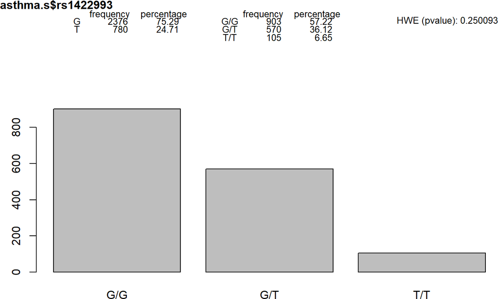

Figure 1: SNP summary  
Bar chart showing the basic information of a given SNP

```r
plot(asthma.s$rs1422993)
```

The argument *type* helps to get a pie chart

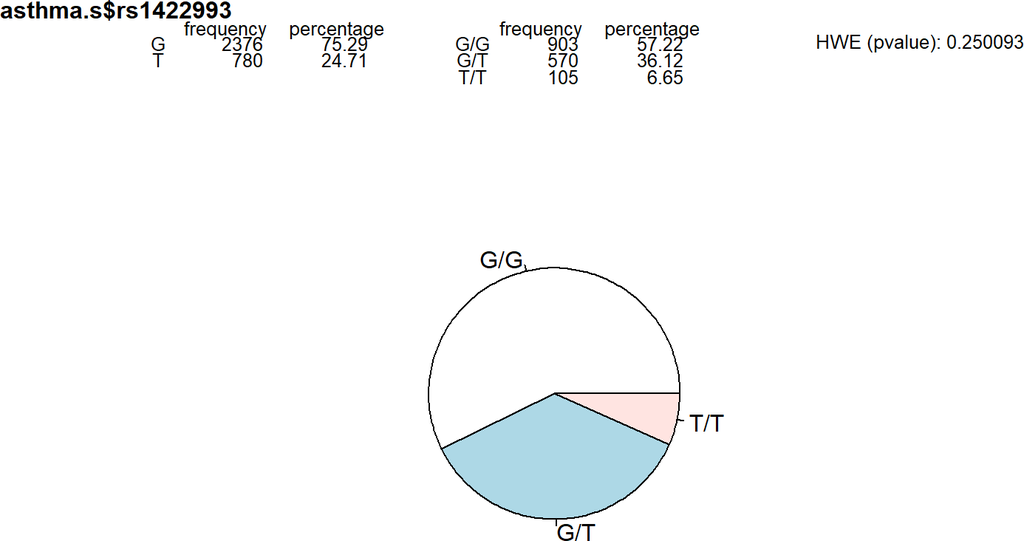

Figure 2: SNP summary  
Pie chart showing the basic information of a given SNP

```r
plot(asthma.s$rs1422993, type=pie)
```

The *summary* function can also be applied to the whole dataset

```r
summary(asthma.s, print=FALSE)
```

```
           alleles major.allele.freq HWE      missing (%)
rs4490198  A/G     59.2              0.174133  0.6
rs4849332  G/T     61.8              0.522060  0.1
rs1367179  G/C     81.4              0.738153  1.0
rs11123242 C/T     81.7              0.932898  0.6
rs13014858 G/A     58.3              0.351116  0.1
rs1430094  G/A     66.9              0.305509  0.4
rs1430093  C/A     66.6              0.817701  3.5
rs746710   G/C     51.5              0.614368  0.0
rs1430090  T/G     70.0              0.025180  1.6
rs6737251  C/T     69.3              0.235996  0.3
rs11685217 C/T     80.1              0.009462  4.5
rs1430097  C/A     65.1              0.738166  1.0
rs10496465 A/G     85.8              0.917997  0.6
rs3756688  T/C     63.9              0.154632  0.6
rs2303063  A/G     53.0              0.722069  1.1
rs1422993  G/T     75.3              0.250093  0.0
rs2400478  G/A     62.6              0.256786  0.9
rs714588   A/G     54.9              0.838329  0.8
rs1023555  T/A     76.8              0.943443  0.5
rs898070   G/A     62.6              1.000000  0.6
rs963218   C/T     53.2              0.389387  0.3
rs1419835  C/T     78.2              0.505391  0.6
rs765023   T/C     64.5              0.030513  6.9
rs1345267  A/G     61.0              0.112183  0.1
rs324381   G/A     64.6              0.242223 11.6
rs184448   T/G     55.9              0.008446  2.2
rs324396   C/T     71.2              0.197291  0.3
rs324957   G/A     57.0              0.007417  0.4
rs324960   C/T     66.6              0.077777  1.1
rs10486657 C/T     81.3              0.672703  4.3
rs324981   A/T     53.2              0.048438  0.2
rs1419780  C/G     80.8              0.569652  0.2
rs325462   T/A     51.0              0.337862  0.3
rs727162   G/C     78.5              0.765708  0.0
rs10250709 G/A     65.4              0.266434  0.0
rs6958905  T/C     64.7              0.377472  0.4
rs10238983 T/C     75.7              0.216435  0.4
rs4941643  A/G     54.1              0.635887  7.2
rs3794381  C/G     71.7              0.652089  7.1
rs2031532  G/A     65.0              0.911918  0.0
rs2247119  T/C     71.5              0.457710  0.5
rs8000149  T/C     63.2              0.588077  0.4
rs2274276  G/C     57.0              0.571386  0.6
rs7332573  G/T     91.5              0.869947  1.5
rs3829366  T/A     51.6              0.722626  1.3
rs6084432  G/A     83.7              0.266716  0.6
rs512625   G/A     69.5              0.905395  0.4
rs3918395  G/T     86.8              0.508732  1.2
rs2787095  G/C     60.2              0.102053  0.8
rs2853215  G/A     73.0              0.249516  0.2
```

showing the SNP labels with minor/major allele format, the major allele frequency the HWE test and the percentage of missing genotypes. Missing values can be further explored plotting with

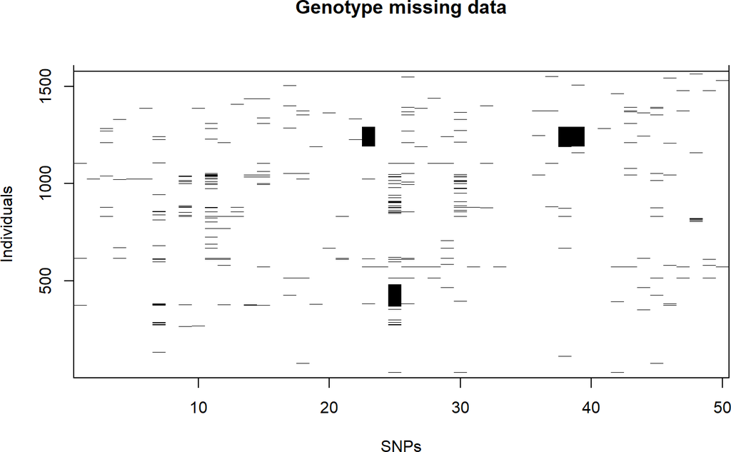

Figure 3: Missing genotypes  
Black squares shows missing genotuype information of asthma data example.

```r
plotMissing(asthma.s, print.labels.SNPs = FALSE)
```

This plot can be used to inspect if missing values appear randomly across individuals and SNPs. In our case, we can see that the missing pattern may be considered random, except for three clusters in consecutive SNPs (large black squares). These individuals should be further checked for possible problems with genotyping.

# 4 Hardy-Weinberg equilibrium

Genotyping of SNPs needs to pass quality control measures. Aside from technical details that need to be considered for filtering SNPs with low quality, genotype calling error can be detected by a HWE test. The test compares the observed genotype frequencies with those expected under random mating, which follows when the SNPs are in the absence of selection, mutation, genetic drift, or other forces. Therefore, HWE must be checked only in controls. There are several tests described in the literature to verify HWE. In `SNPassoc` HWE is tested for all the bi-allelic SNP markers using a fast exact test Wigginton, Cutler, and Abecasis (2005) implemented in the *tableHWE* function.

```r
hwe <- tableHWE(asthma.s)
head(hwe)
```

```
           HWE (p value)
rs4490198      0.1741325
rs4849332      0.5220596
rs1367179      0.7381531
rs11123242     0.9328981
rs13014858     0.3511162
rs1430094      0.3055089
```

We observe that the first SNPs in the dataset are under HWE since their P-values rejecting the HWE hypothesis (null hypothesis) are larger than 0.05. However, when tested in control samples only, by stratifying by cases and controls

```r
hwe2 <- tableHWE(asthma.s, casecontrol)

#SNPs is HWE in the whole sample but not controls
snpNHWE <- hwe2[,1]>0.05 & hwe2[,2]<0.05
rownames(hwe2)[snpNHWE]
```

```
[1] "rs1345267"
```

```r
hwe2[snpNHWE,]
```

```
all groups          0          1
0.11218285 0.04956349 0.81604706
```

We see that rs1345267 is not in HWE within controls because its P-value is <0.05. Notice that one is interested in keeping those SNPsthat do not reject the null hypothesis. As several SNPs are tested, multiple comparisons must be considered. In this particular setting, a threshold of 0.001 is normally considered. As a quality control measure, it is not necessary to be as conservative as in those situations where false discovery rates need to be controlled.

SNPs that do not pass the HWE test must be removed form further analyses. We can recall *setupSNP* and indicate the columns of the SNPs to be kept

```r
snps.ok <- rownames(hwe2)[hwe2[,2]>=0.001]
pos <- which(colnames(asthma)%in%snps.ok, useNames = FALSE)
asthma.s <- setupSNP(asthma, pos, sep="")
```

Note that in the variable *pos* we redefine the SNP variables to be considered as class *snp*.

# 5 SNP association analysis

We are interested in finding those SNPs associated with asthma status that is encoded in the variable *casecontrol*. We first illustrate the association between case-control status and the SNP rs1422993. The association analysis for all genetic models is performed by the function *association* that regresses *casecontrol* on the variable rs1422993 from the dataset *asthma.s* that already contains the SNP variables of class *snp*.

```r
association(casecontrol ~ rs1422993, data = asthma.s)
```

```
SNP: rs1422993  adjusted by:
                0    %   1    %   OR lower upper  p-value  AIC
Codominant
G/G           730 59.0 173 50.9 1.00             0.017768 1642
G/T           425 34.3 145 42.6 1.44  1.12  1.85
T/T            83  6.7  22  6.5 1.12  0.68  1.84
Dominant
G/G           730 59.0 173 50.9 1.00             0.007826 1642
G/T-T/T       508 41.0 167 49.1 1.39  1.09  1.77
Recessive
G/G-G/T      1155 93.3 318 93.5 1.00             0.877863 1649
T/T            83  6.7  22  6.5 0.96  0.59  1.57
Overdominant
G/G-T/T       813 65.7 195 57.4 1.00             0.005026 1641
G/T           425 34.3 145 42.6 1.42  1.11  1.82
log-Additive
0,1,2        1238 78.5 340 21.5 1.22  1.01  1.47 0.040151 1644
```

The function *association* follows the usual syntax of R modelling functions with the difference that the variables in the model that are of class *snp* are tested using different genetic models. In our example, we observe that all genetic models but the recessive one are statistically significant. *association* also fits the overdominant model, which compares the two homozygous genotypes versus the heterozygous one. This genetic model of inheritance is biologically rare although it has been linked to sickle cell anemia in humans. The result table describes the number of individuals in each genotype across cases and controls. The ORs and CI-95% are also computed. The last column describes the AIC (Akaike information criteria) that can be used to decide which is the best model of inheritance; the lower the better the model is.

```r
maxstat(asthma.s$casecontrol, asthma.s$rs1422993)
```

```
     dominant recessive log-additive MAX-statistic Pr(>z)
[1,]    7.073     0.024        4.291         7.073 0.0142 *
---
Signif. codes:  0 '***' 0.001 '**' 0.01 '*' 0.05 '.' 0.1 ' ' 1
```

If an expected model of inheritance is hypothesized, the association analysis for the model can be specified in the argument *model*, which by default test all models,

```r
association(casecontrol ~ rs1422993, asthma.s, model="dominant")
```

```
SNP: rs1422993  adjusted by:
           0  %   1    %   OR lower upper  p-value  AIC
Dominant
G/G      730 59 173 50.9 1.00             0.007826 1642
G/T-T/T  508 41 167 49.1 1.39  1.09  1.77
```

Association tests are typically adjusted by covariates, which are incorporated in the model in the usual form

```r
association(casecontrol ~ rs1422993 + country + smoke, asthma.s)
```

```
SNP: rs1422993  adjusted by: country smoke
                0    %   1    %   OR lower upper p-value  AIC
Codominant
G/G           728 59.1 173 51.0 1.00             0.06940 1408
G/T           423 34.3 144 42.5 1.38  1.05  1.82
T/T            81  6.6  22  6.5 1.06  0.61  1.85
Dominant
G/G           728 59.1 173 51.0 1.00             0.03429 1407
G/T-T/T       504 40.9 166 49.0 1.33  1.02  1.73
Recessive
G/G-G/T      1151 93.4 317 93.5 1.00             0.79338 1411
T/T            81  6.6  22  6.5 0.93  0.54  1.60
Overdominant
G/G-T/T       809 65.7 195 57.5 1.00             0.02147 1406
G/T           423 34.3 144 42.5 1.37  1.05  1.80
log-Additive
0,1,2        1232 78.4 339 21.6 1.19  0.96  1.46 0.11191 1409
```

ORs for stratified analysis on given categorical covariates are used to verify whether the risk is constant across groups

```r
association(casecontrol ~ rs1422993 + survival::strata(gender), asthma.s)
```

```
SNP: rs1422993  adjusted by: survival::strata(gender)
                0    %   1    %   OR lower upper  p-value  AIC
Codominant
G/G           730 59.0 173 50.9 1.00             0.022940 1634
G/T           425 34.3 145 42.6 1.42  1.11  1.83
T/T            83  6.7  22  6.5 1.09  0.66  1.80
Dominant
G/G           730 59.0 173 50.9 1.00             0.011144 1633
G/T-T/T       508 41.0 167 49.1 1.37  1.07  1.74
Recessive
G/G-G/T      1155 93.3 318 93.5 1.00             0.805330 1640
T/T            83  6.7  22  6.5 0.94  0.58  1.53
Overdominant
G/G-T/T       813 65.7 195 57.4 1.00             0.006378 1632
G/T           425 34.3 145 42.6 1.41  1.10  1.80
log-Additive
0,1,2        1238 78.5 340 21.5 1.21  1.00  1.46 0.055231 1636
```

```r
association(casecontrol ~ rs1422993, asthma.s,
                subset=country=="Spain")
```

```
SNP: rs1422993  adjusted by:
               0    %  1    %   OR lower upper p-value   AIC
Codominant
G/G          179 54.6 22 44.9 1.00              0.3550 295.2
G/T          125 38.1 24 49.0 1.56  0.84  2.91
T/T           24  7.3  3  6.1 1.02  0.28  3.66
Dominant
G/G          179 54.6 22 44.9 1.00              0.2059 293.7
G/T-T/T      149 45.4 27 55.1 1.47  0.81  2.70
Recessive
G/G-G/T      304 92.7 46 93.9 1.00              0.7576 295.2
T/T           24  7.3  3  6.1 0.83  0.24  2.85
Overdominant
G/G-T/T      203 61.9 25 51.0 1.00              0.1502 293.2
G/T          125 38.1 24 49.0 1.56  0.85  2.85
log-Additive
0,1,2        328 87.0 49 13.0 1.23  0.77  1.96  0.3816 294.5
```

These analyses can be also be performed in quantitative traits, such as body mass index, since *association* function automatically selects the error distribution of the regression analysis (either Gaussian or binomial).

```r
association(bmi ~ rs1422993, asthma.s)
```

```
SNP: rs1422993  adjusted by:
                n    me     se       dif   lower  upper p-value  AIC
Codominant
G/G           896 25.53 0.1446  0.000000                 0.9069 9069
G/T           565 25.50 0.1834 -0.027059 -0.4874 0.4332
T/T           105 25.71 0.4676  0.178076 -0.7057 1.0619
Dominant
G/G           896 25.53 0.1446  0.000000                 0.9818 9067
G/T-T/T       670 25.54 0.1710  0.005089 -0.4324 0.4426
Recessive
G/G-G/T      1461 25.52 0.1135  0.000000                 0.6694 9067
T/T           105 25.71 0.4676  0.188540 -0.6769 1.0540
Overdominant
G/G-T/T      1001 25.55 0.1383  0.000000                 0.8424 9067
G/T           565 25.50 0.1834 -0.045739 -0.4965 0.4050
log-Additive
0,1,2                           0.033951 -0.3153 0.3832  0.8489 9067
```

For BMI, *association* tests whether the difference between means is statistically significant, rather than computing an OR.

For multiple SNP data, our objective is to identify the variants that are significantly associated with the trait. The most basic strategy is, therefore, to fit an association test like the one described above for each of the SNPs in the dataset and determine which of those associations are significant. The massive univariate testing is the most widely used analysis method for *omic* data because of its simplicity. In *SNPassoc*, this type of analysis is done with the function *WGassociation*

```r
ans <- WGassociation(casecontrol, data=asthma.s)
head(ans)
```

```
           comments codominant dominant recessive overdominant log-additive
rs4490198         -    0.52765  0.29503   0.96400      0.29998      0.49506
rs4849332         -    0.96912  0.92986   0.84806      0.82327      0.97049
rs1367179         -    0.62775  0.59205   0.35786      0.86419      0.43994
rs11123242        -    0.68622  0.67596   0.39801      0.92878      0.52009
rs13014858        -    0.52578  0.26739   0.88011      0.34966      0.40897
rs1430094         -    0.13375  0.10569   0.54432      0.04490      0.36611
```

Here, only the outcome is required in the formula argument (first argument) since the function successively calls *association* on each of the variables of class *snp* within *data*. The function returns the P-values of association of each SNP under each genetic model. Covariates can also be introduced in the model

```r
ans.adj <- WGassociation(casecontrol ~ country + smoke, asthma.s)
head(ans.adj)
```

[output not shown]

`SNPassoc` is computationally limited on large genomic data. The computing time can be reduced by parallelization, specifying in the argument *mc.cores* the number of computing cores to be used. Alternatively, the function *scanWGassociation*, a C compiled function, can be used to compute a predetermined genetic model across all SNPs, passed in the argument *model*, which by default is the additive model

```
ans.fast <- scanWGassociation(casecontrol, asthma.s)
```

**NOTE**: This function is not available on the `SNPassoc` version available on CRAN. The user can install the development version available on GitHub to get access to this function just executing

```r
devtools::install_github("isglobal-brge/SNPassoc")
```

The P-values obtained from massive univariate analyses are visualized with the generic *plot* function

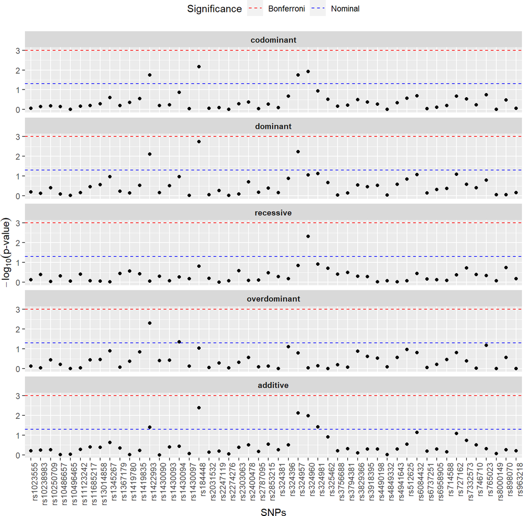

Figure 4: Manhattan-type plots for different genetic models  
P-values in -log10 scale to assess the association between case-control status and SNPs in the asthma example.

```r
plot(ans)
```

Maximum-statistic (see González et al. (2008)) can also be used to test association between asthma status and SNPs

```r
ans.max <- maxstat(asthma.s, casecontrol)
ans.max
```

```
           dominant recessive log-additive MAX-statistic Pr(>z)
rs4490198     1.097     0.002        0.466         1.097 0.5026
rs4849332     0.008     0.037        0.001         0.037 0.9764
rs1367179     0.287     0.845        0.602         0.845 0.5888
rs11123242    0.175     0.714        0.417         0.714 0.6388
rs13014858    1.230     0.023        0.683         1.230 0.4640
rs1430094     2.617     0.368        0.821         2.617 0.2070
rs1430093     1.051     0.042        0.743         1.051 0.5184
rs746710      0.728     0.679        1.051         1.051 0.5165
rs1430090     0.172     0.463        0.000         0.463 0.7428
rs6737251     0.143     0.156        0.217         0.217 0.8686
rs11685217    0.894     0.030        0.705         0.894 0.5682
rs1430097     0.003     0.183        0.029         0.183 0.8883
rs10496465    0.003     0.020        0.008         0.020 0.9872
rs3756688     0.016     0.738        0.266         0.738 0.6257
rs2303063     0.060     1.271        0.658         1.271 0.4527
rs1422993     7.073     0.024        4.291         7.073 0.0183 *
rs2400478     1.662     0.056        1.055         1.662 0.3591
rs714588      0.659     0.061        0.150         0.659 0.6582
rs1023555     0.221     0.104        0.261         0.261 0.8462
rs898070      0.020     1.794        0.346         1.794 0.3324
rs963218      0.165     0.190        0.263         0.263 0.8434
rs1419835     1.084     0.775        0.295         1.084 0.5107
rs765023      1.959     0.526        0.483         1.959 0.3033
rs1345267     2.582     0.003        1.383         2.582 0.2101
rs324381      0.175     0.402        0.377         0.402 0.7744
rs184448      9.710     2.026        8.253         9.710 0.0033 **
rs324396      2.312     0.188        1.051         2.312 0.2492
rs324957      7.598     2.134        7.157         7.598 0.0134 *
rs324960      2.901     7.928        6.443         7.928 0.0113 *
rs10486657    0.054     0.500        0.001         0.500 0.7303
rs324981      3.168     2.431        4.270         4.270 0.0839 .
rs1419780     0.123     1.193        0.005         1.193 0.4782
rs325462      1.545     1.645        2.412         2.412 0.2331
rs727162      3.022     0.643        3.074         3.074 0.1624
rs10250709    0.737     0.007        0.360         0.737 0.6284
rs6958905     0.490     0.099        0.447         0.490 0.7324
rs10238983    0.094     0.692        0.328         0.692 0.6478
rs4941643     1.294     0.006        0.465         1.294 0.4473
rs3794381     0.127     0.998        0.489         0.998 0.5357
rs2031532     0.025     0.240        0.127         0.240 0.8572
rs2247119     0.379     0.000        0.229         0.379 0.7843
rs8000149     0.020     0.043        0.043         0.043 0.9726
rs2274276     0.005     0.034        0.023         0.034 0.9781
rs7332573     1.247     1.703        1.825         1.825 0.3298
rs3829366     1.137     0.448        0.069         1.137 0.4909
rs6084432     2.999     0.848        3.279         3.279 0.1435
rs512625      2.180     0.030        1.119         2.180 0.2643
rs3918395     0.903     0.414        0.455         0.903 0.5714
rs2787095     0.178     0.069        0.184         0.184 0.8867
rs2853215     0.686     0.931        1.130         1.130 0.4931
---
Signif. codes:  0 '***' 0.001 '**' 0.01 '*' 0.05 '.' 0.1 ' ' 1
```

```r
#minimum P-value across SNPs
min(ans.max["Pr(>z)",])
```

```
[1] 0.003304715
```

Information for specific association models for given SNPs can also be retrieved with *WGstats*

```r
infoTable <- WGstats(ans)
```

Therefore, we can have access to the results for a given SNP by

```r
infoTable$rs1422993
```

```
SNP: rs1422993  adjusted by:
                0    %   1    %   OR lower upper  p-value  AIC
Codominant
G/G           730 59.0 173 50.9 1.00             0.017768 1642
G/T           425 34.3 145 42.6 1.44  1.12  1.85
T/T            83  6.7  22  6.5 1.12  0.68  1.84
Dominant
G/G           730 59.0 173 50.9 1.00             0.007826 1642
G/T-T/T       508 41.0 167 49.1 1.39  1.09  1.77
Recessive
G/G-G/T      1155 93.3 318 93.5 1.00             0.877863 1649
T/T            83  6.7  22  6.5 0.96  0.59  1.57
Overdominant
G/G-T/T       813 65.7 195 57.4 1.00             0.005026 1641
G/T           425 34.3 145 42.6 1.42  1.11  1.82
log-Additive
0,1,2        1238 78.5 340 21.5 1.22  1.01  1.47 0.040151 1644
```

recovering our previous results given by *association* function.

**NOTE**: The R output of specific association analyses can be exported into LaTeX by using *getNiceTable* function and *xtable* R package. The following code creates a table for the SNPs rs1422993 and rs184448

```r
library(xtable)
out <- getNiceTable(ans[c("rs1422993", "rs184448")])

nlines <- attr(out, "nlines")
hlines <- c(-1, -1, 0, cumsum(nlines+1), nrow(out), nrow(out))

print(xtable(out, caption='Genetic association using
                different genetic models from asthma
                data example of rs1422993 and rs184448
                SNPs obtained with SNPassoc.',
             label = 'tab-2SNPs'),
      tabular.enviroment="longtable", file="tableSNPs",
      floating=FALSE,  include.rownames = FALSE,
      hline.after= hlines, sanitize.text.function=identity)
```

# 6 Gene-environment and gene-gene interactions

Gene-enviroment (GxE) analyses can be performed within `SNPassoc` using *association* function. Assume that we are interested in testing whether the risk of rs1422993 for asthma under the dominant model is different among smokers (variable smoke; 0=never, 1=ever). This code fits a model with an interaction term where the environmental variable is required to be a factor factor variable.

```r
association(casecontrol ~ dominant(rs1422993)*factor(smoke),
            data=asthma.s)
```

```
      SNP: dominant(rs1422993  adjusted by:
 Interaction
---------------------
          0       OR lower upper   1      OR lower upper
G/G     486 130 1.00    NA    NA 242 43 0.66  0.46  0.97
G/T-T/T 354 128 1.35  1.02  1.79 150 38 0.95  0.63  1.42

p interaction: 0.8513

 factor(smoke) within dominant(rs1422993
---------------------
G/G
    0   1   OR lower upper
0 486 130 1.00    NA    NA
1 242  43 0.66  0.46  0.97

G/T-T/T
    0   1  OR lower upper
0 354 128 1.0    NA    NA
1 150  38 0.7  0.47  1.06

p trend: 0.8513

 dominant(rs1422993 within factor(smoke)
---------------------
0
          0   1   OR lower upper
G/G     486 130 1.00    NA    NA
G/T-T/T 354 128 1.35  1.02  1.79

1
          0  1   OR lower upper
G/G     242 43 1.00    NA    NA
G/T-T/T 150 38 1.43  0.88  2.31

p trend: 0.8513
```

In a similar way, gene-gene interaction (GxG) of a given SNP epistasis model can also be fitted using the same function. In that case, the genetic model of the interacting SNP must be indicated in the *model.inteaction* argument.

```r
association(casecontrol ~ rs1422993*factor(rs184448),
            data=asthma.s, model.interaction = "dominant" )
```

```
      SNP: rs1422993  adjusted by:
 Interaction
---------------------
        T/T      OR lower upper T/G      OR lower upper   0  1  G/G lower upper
G/G     227 43 1.00    NA    NA 359 96 1.41  0.95  2.10 128 30 1.24  0.74  2.07
G/T-T/T 154 33 1.13  0.69  1.86 265 93 1.85  1.24  2.77  78 38 2.57  1.55  4.27

p interaction: 0.24499

 factor(rs184448) within rs1422993
---------------------
G/G
      0  1   OR lower upper
T/T 227 43 1.00    NA    NA
T/G 359 96 1.41  0.95  2.10
G/G 128 30 1.24  0.74  2.07

G/T-T/T
      0  1   OR lower upper
T/T 154 33 1.00    NA    NA
T/G 265 93 1.64  1.05  2.55
G/G  78 38 2.27  1.32  3.90

p trend: 0.24499

 rs1422993 within factor(rs184448)
---------------------
T/T
          0  1   OR lower upper
G/G     227 43 1.00    NA    NA
G/T-T/T 154 33 1.13  0.69  1.86

T/G
          0  1   OR lower upper
G/G     359 96 1.00    NA    NA
G/T-T/T 265 93 1.31  0.95  1.82

G/G
          0  1   OR lower upper
G/G     128 30 1.00    NA    NA
G/T-T/T  78 38 2.08  1.19  3.62

p trend: 0.12743
```

We observe that the interaction between these two SNPs is not statistically significant (P-value=0.24). However, the OR of GG genotype of rs184448 differs across individuals between the GG and GT-TT genotypes of rs1422993 (see ORs for GG in the second table of the output).

The user also can perform GxG for a set of SNPs using this code. Let us assume we are interested in assessing interaction between the SNPs that are significant at 10% level

```r
ans <- WGassociation(casecontrol, data=asthma.s)
mask <- apply(ans, 1, function(x) min(x, na.rm=TRUE)<0.1)
sig.snps <- names(mask[mask])
sig.snps
```

```
 [1] "rs1430094" "rs1422993" "rs765023"  "rs184448"  "rs324396"  "rs324957"
 [7] "rs324960"  "rs324981"  "rs727162"  "rs6084432"
```

```r
idx <- which(colnames(asthma)%in%sig.snps)
asthma.s2 <- setupSNP(asthma, colSNPs = idx, sep="")
ans.int <- interactionPval(casecontrol ~ 1, data=asthma.s2)
ans.int
```

```
            rs1430094   rs1422993    rs765023    rs184448    rs324396
rs1430094 0.132526514 0.653457029 0.816154586 0.787386835 0.694311497
rs1422993 0.140433948 0.016719949 0.133131712 0.375246182 0.683959376
rs765023  0.171993821 0.144029395 0.182805988 0.961405419 0.194520134
rs184448  0.100074594 0.019963426 0.034666219 0.007969948 0.036825613
rs324396  0.204742661 0.190583402 0.131945703 0.344952544 0.209589962
rs324957  0.103680541 0.019820456 0.034446832 0.696623215 0.318903026
rs324960  0.107216765 0.024180405 0.174801032 0.291457716 0.584132142
rs324981  0.128489057 0.144077239 0.153521356 0.646139555 0.301782199
rs727162  0.258828613 0.240900610 0.188971595 0.173341993 0.120240909
rs6084432 0.214413938 0.187372912 0.187830183 0.264160389 0.252965105
             rs324957    rs324960    rs324981    rs727162   rs6084432
rs1430094 0.644661690 0.096913557 0.774083175 0.043758067 0.946641185
rs1422993 0.257661509 0.175946789 0.095251421 0.577504655 0.027437424
rs765023  0.437535350 0.614095008 0.117705086 0.217580773 0.896707843
rs184448  0.018290318 0.356124918 0.311031078 0.297592380 0.349332875
rs324396  0.232076552 0.747574191 0.064231657 0.361336095 0.388626207
rs324957  0.019578585 0.595796247 0.965290164 0.402781904 0.272919867
rs324960  0.404830873 0.017401694 0.168077057 0.406220478 0.725774374
rs324981  0.657378128 0.533095852 0.117043376 0.463436271 0.862291944
rs727162  0.174960014 0.500811687 0.167364803 0.206131411 0.885294485
rs6084432 0.174006927 0.146808311 0.210647392 0.203957720 0.193711884
```

we can visualize the results by

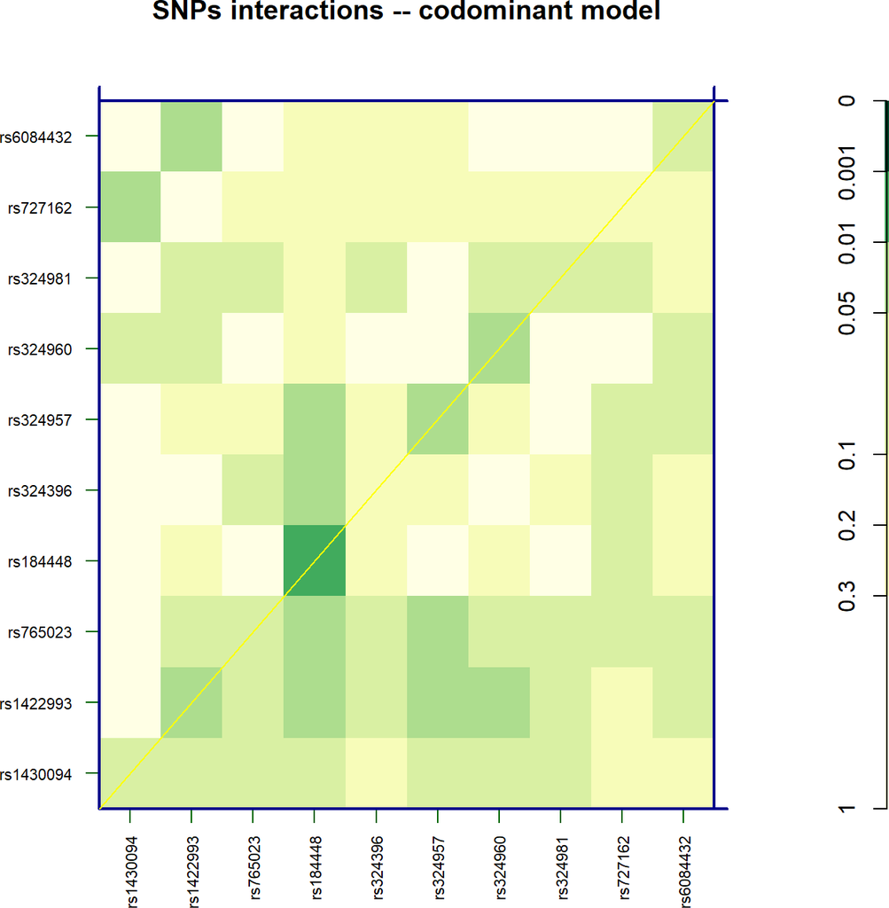

Figure 5: Interaction plot  
Interaction plot of SNPs significant al 10% significant level (see help of ‘interactionPval’ function to see what is represented in the plot).

```r
plot(ans.int)
```

# 7 Haplotype analysis

Genetic association studies can be extended from single SNP associations to haplotype associations. Several examples including different complex diseases can be found in . While alleles naturally occur in haplotypes, as they belong to chromosomes, the phase, or the knowledge of the chromosome an allele belongs to is lost in the genotyping process. As each genotype is measured with a different probe the phase between the alleles in a chromosome is broken. Consider for instance an individual for which one chromosome has alleles A and T at two different loci and alleles G or C at the second chromosome. The individual’s genotypes for the individual at the two loci are A/G and T/C, which are the same genotypes of another individual that has alleles A and C in one chromosome and G and T in the second chromosome. Clearly, if the pair A-T confers a risk to a disease, subject one is at risk while subject two is not, despite both of them having the same genotypes.

The only unequivocal method of resolving phase ambiguity is sequencing the chromosomes of individuals. However, given the correlational structure of SNPs, it is possible to estimate the probability of a particular haplotype in a subject. This can be done in a genetic association study where a number of cases and controls are genotyped. There are numerous methods to infer unobserved haplotypes, two of the most popular are maximum likelihood, implemented via the expectation-maximization (EM) algorithm , and a parsimony method . Recent methods based on Bayesian models have also been proposed . In addition, haplotypes inferences carry uncertainty, which should be considered in association analyses.

## 7.1 Haplotype estimation

We now illustrate how to perform haplotype estimation from genotype data using the EM algorithm and how to integrate haplotype uncertainty when evaluating the association between traits and haplotypes. Haplotype inference is performed with `haplo.stats`, for which genotypes are encoded in a different format. *make.geno*, from `SNPassoc`, formats data for `haplo.stats`. The function *haplo.em* computes the haplotype frequency in the data for the SNPs of interest. Here we illustrate how to estimate haplotypes built from the SNPs rs714588, rs1023555 and rs898070:

```r
library(haplo.stats)
snpsH <- c("rs714588", "rs1023555",  "rs898070")
genoH <- make.geno(asthma.s, snpsH)
em <- haplo.em(genoH, locus.label = snpsH, miss.val = c(0, NA))
em
```

```
================================================================================
                                   Haplotypes
================================================================================
  rs714588 rs1023555 rs898070 hap.freq
1        1         1        1  0.04090
2        1         1        2  0.02439
3        1         2        1  0.04265
4        1         2        2  0.44047
5        2         1        1  0.08271
6        2         1        2  0.08403
7        2         2        1  0.20794
8        2         2        2  0.07691
================================================================================
                                    Details
================================================================================
lnlike =  -4102.691
lr stat for no LD =  774.5411 , df =  4 , p-val =  0
```

Coding the common and variant alleles as 1 and 2, we can see there are 8 possible haplotypes across the subjects and are listed with an estimated haplotype frequency. Clearly, the haplotypes are not equally probable, as expected from the high LD between the SNPs. In particular, we observe that haplotypes 4 and 7 are the most probable, accumulating 65% of the haplotype sample. *haplo.em* estimates for each subject the probability of a given haplotype in each of the subject’s chromosomes.

## 7.2 Haplotype association

We then want to assess if any of these haplotypes significantly associates with asthma. The *haplo.glm* fits a regression model between the phenotype and the haplotypes, incorporating the uncertainty for the probable haplotypes of individuals. The function *intervals* of `SNPassoc` provides a nice summary of the results

```r
trait <- asthma.s$casecontrol
mod <- haplo.glm(trait ~ genoH,
                 family="binomial",
                 locus.label=snpsH,
                 allele.lev=attributes(genoH)$unique.alleles,
                 control = haplo.glm.control(haplo.freq.min=0.05))
intervals(mod)
```

```
               freq   or   95%   C.I.   P-val
         ATG 0.4405   1.00 Reference haplotype
         GAA 0.0827   1.09 (   0.77 -   1.56 )  0.6160
         GAG 0.0841   0.99 (   0.69 -   1.42 )  0.9642
         GTA 0.2080   1.06 (   0.84 -   1.34 )  0.6379
         GTG 0.0769   1.09 (   0.76 -   1.58 )  0.6367
  genoH.rare 0.1079   1.15 (   0.83 -   1.59 )  0.3968
```

*haplo.glm* fits a logistic regression model for the asthma status (*trait* - NOTE: this must be a 0/1 variable) on the inferred haplotypes (*genoH*), the names of SNPs and their allele names are passed in the *locus.label* and *allele.lev* arguments, while only haplotypes with at least 5% frequency are considered. As a result, we obtain the OR for each haplotype with their significance P-value, with respect to the most common haplotype (ATG with 44% frequency). In particular, from this analysis, we cannot see any haplotype significantly associated with asthma.

## 7.3 Sliding window approach

The inference of haplotypes depends on a predefined region or sets of SNPs. For instance, in the last section, we selected three SNPs that were in high LD. However, when no previous knowledge is available about the region or SNPs for which haplotypes should be inferred, we can apply a sliding window for haplotype inference .

To illustrate this type of analysis, we now consider a second block of 10 SNPs in our asthma example (from 6th to 15th SNP). Considering large haplotypes, however, increases the number of possible haplotypes in the sample, decreasing the power of finding real associations. In addition, in predefined blocks, it is possible to miss the most efficient length of the susceptible haplotype, incrementing the loss of power. This is overcome using a sliding window. We thus ask which is the haplotype combination from any of 4, 5, 6 or 7 consecutive SNPs that gives the highest association with asthma status. We then reformat SNP genotypes in the region with the *make.geno* function and perform an association analysis for multiple haplotypes of *i* SNPs sliding from the 6th to the 15th SNP in the data. We perform an analysis for each window length *i* varying from 4 to 7 SNPs.

```r
snpsH2 <- labels(asthma.s)[6:15]
genoH2 <- make.geno(asthma.s, snpsH2)
haplo.score <- list()
for (i in 4:7) {
 trait <- asthma.s$casecontrol
 haplo.score[[i-3]] <- haplo.score.slide(trait, genoH2,
                          trait.type="binomial",
                          n.slide=i,
                          simulate=TRUE,
                          sim.control=score.sim.control(min.sim=100,
                                       max.sim=200))
 }
```

The results can be visualized with the following plot

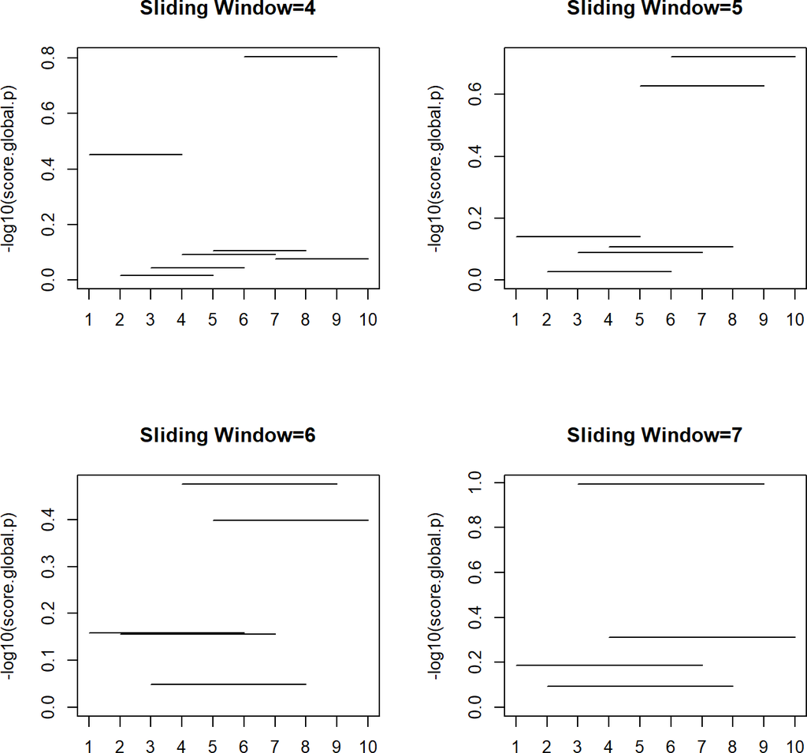

Figure 6: Sliding window approach  
Results obtained of varying haplotype size from 4 up to 7 of 6th to the 15th SNP from asthma data example

```r
par(mfrow=c(2,2))
for (i in 4:7) {
    plot(haplo.score[[i-3]])
    title(paste("Sliding Window=", i, sep=""))
 }
```

```r
snpsH3 <- snpsH2[4:7]
genoH3 <- make.geno(asthma.s, snpsH3)
mod <- haplo.glm(trait~genoH3,
                 family="binomial",
                 locus.label=snpsH3,
                 allele.lev=attributes(genoH3)$unique.alleles,
                 control = haplo.glm.control(haplo.freq.min=0.05))
intervals(mod)
```

```
               freq   or   95%   C.I.   P-val
        TCCC 0.3521   1.00 Reference haplotype
        GCCC 0.2963   1.01 (   0.82 -   1.24 )  0.9495
        TTCA 0.1184   0.89 (   0.67 -   1.20 )  0.4433
        TTTA 0.1830   1.12 (   0.87 -   1.43 )  0.3796
 genoH3.rare 0.0502   0.78 (   0.50 -   1.22 )  0.2750
```

```r
lrt <- mod$lrt
pchisq(lrt$lrt, lrt$df, lower=FALSE)
```

```
[1] 0.5044641
```

We can also test the association between asthma and the haplotype adjusted for smoking status

```r
smoke <- asthma.s$smoke
mod.adj.ref <- glm(trait ~ smoke, family="binomial")
mod.adj <- haplo.glm(trait ~ genoH3 + smoke ,
                 family="binomial",
                 locus.label=snpsH3,
                 allele.lev=attributes(genoH3)$unique.alleles,
                 control = haplo.glm.control(haplo.freq.min=0.05))

lrt.adj <- mod.adj.ref$deviance - mod.adj$deviance
pchisq(lrt.adj, mod.adj$lrt$df, lower=FALSE)
```

```
[1] 0.6457956
```

# References

González, Juan R, Lluı́s Armengol, Xavier Solé, Elisabet Guinó, Josep M Mercader, Xavier Estivill, and Vı́ctor Moreno. 2007. “SNPassoc: An R Package to Perform Whole Genome Association Studies.” *Bioinformatics* 23 (5): 654–55.

González, Juan R, Josep L Carrasco, Frank Dudbridge, Lluı́s Armengol, Xavier Estivill, and Victor Moreno. 2008. “Maximizing Association Statistics over Genetic Models.” *Genetic Epidemiology* 32 (3): 246–54.

Wigginton, Janis E, David J Cutler, and Gonçalo R Abecasis. 2005. “A Note on Exact Tests of Hardy-Weinberg Equilibrium.” *The American Journal of Human Genetics* 76 (5): 887–93.